# Brachial-ankle pulse-wave velocity in a Japanese health-check cohort

Dataset 9: Liver enzymes and arterial stiffness in a Japanese health-check cohort

RSR feasibility analysis

2026-08-03

# Introduction

Between 2008 and 2010 a general health-check programme in Japan enrolled 912 men and women aged 24 to 84 years and measured brachial-ankle pulse-wave velocity (baPWV) with an automatic waveform analyser alongside a standard panel of anthropometric, haemodynamic and biochemical measurements; the cohort was assembled to ask whether serum gamma-glutamyltranspeptidase (GGT) marks arterial disease, and is reported in *BMJ Open* 2014;4:e005413. Pulse-wave velocity is the reference non-invasive measure of arterial stiffness and predicts cardiovascular events independently of blood pressure, so identifying which routinely collected characteristics track with it is a natural question for a screening programme.

**Aim.** Among these health-check attendees, we examined which of age, sex, body mass index, systolic blood pressure, smoking status, alcohol intake, regular exercise, fasting glucose, triglycerides, HDL cholesterol, kidney function and log2 gamma-GT are independently associated with baPWV, mutually adjusting for the others.

This is a *Purpose 3* analysis: several predictors are of interest and the question is which remain associated with the outcome after mutual adjustment.

# Methods

**Data source.** A cross-sectional Japanese health-check cohort of 912 adults attending a medical health check-up programme that included ultrasound of the liver, a fasting blood panel and automated measurement of brachial-ankle pulse-wave velocity and the ankle-brachial index. Attendance was voluntary, so this is a self-selected screening population rather than a community sample.

**Variables.** The outcome is `pwv_max`, brachial-ankle pulse-wave velocity in cm/s (the higher of the two legs), treated as continuous; higher values mean stiffer arteries. Predictors are age (years), sex (reference Male, the larger group at 592 of 912), BMI (kg/m2), systolic blood pressure (mmHg), smoking status (three levels, reference Never, the largest group at 461), alcohol intake (g/week), regular exercise (reference No, the unexposed and larger group), fasting glucose (mg/dL), triglycerides (mg/dL), HDL cholesterol (mg/dL), estimated glomerular filtration rate (mL/min/1.73m2) and gamma-GT on a log2 scale (so a one-unit increase is a doubling of GGT).

**The predictor set was cut from 18 to 12 before any model was fitted.** With 883 complete cases and 13 estimated parameters this model has about 68 observations per parameter, so the *arithmetic* budget of 10-15 observations per parameter would in principle have tolerated all 18. The cut was made for two other reasons. First, **redundancy**: the 18 suggested predictors contain three sets of near-duplicates. Systolic and diastolic pressure correlate at r = 0.90, and in a model containing both their variance inflation factors are 5.4 and 5.7. The four lipid measures are worse: regressing total cholesterol on LDL, HDL and triglycerides reproduces it almost exactly (R-squared 0.955, with coefficients 1.00, 1.06 and 0.17 - that is, the Friedewald identity total = LDL + HDL + triglycerides/5), and with all four in the model the VIFs reach 23.9 for total cholesterol and 19.7 for LDL. The three liver enzymes are the third set (ALT and AST correlate at r = 0.78). Second, **interpretability**: a table of 18 mutually adjusted coefficients cannot be read as an answer to “which predictors survive adjustment”, which is the question this analysis is asked to answer. We therefore kept one variable per construct: systolic pressure (the stronger correlate of baPWV, r = 0.51 versus 0.46 for diastolic) in place of both pressures; HDL cholesterol and triglycerides (the two metabolic-syndrome lipid components, VIFs 5.5 and 4.6 even in the 18-variable model) in place of all four lipids; and log2 gamma-GT, the enzyme of interest in the source paper, in place of all three enzymes. Uric acid was dropped because it has no distinct a priori role once adiposity and kidney function are in the model (it correlates r = -0.30 with eGFR and r = 0.35 with triglycerides).

**Systolic pressure is retained deliberately but is not innocent.** baPWV is computed from a cuff-based pressure waveform, and arterial stiffness and blood pressure are mutually causal: stiff arteries raise systolic pressure, and higher distending pressure raises the measured velocity in an elastic tube. Adjusting for systolic pressure is therefore partly adjustment for a common cause and partly adjustment for a mediator or even for part of the measurement itself. We report the main model with systolic pressure included, and a sensitivity model omitting it, and interpret the two together.

**Statistical analysis.** `lm()`, justified because the outcome is a continuous measurement in cm/s. We fitted a univariable model for each predictor first, then a single multivariable model containing all of them. Predictors were chosen in advance on subject-matter grounds, not by significance. Significance threshold 0.05; estimates are reported with 95% confidence intervals. Assumptions were checked with `performance::check_model()`, `check_heteroscedasticity()` and `check_collinearity()`, and because non-constant variance was flagged we additionally report HC3 heteroscedasticity-consistent standard errors. Analysis used R version 4.6.0 (2026-04-24) with tidyverse, gtsummary and performance.

**Missing data.** Complete-case analysis: 883 of 912 rows were analysed (29 dropped). The outcome itself is complete; the whole loss comes from `regular_exercise` (16 missing) and `alcohol_g_per_week` (13 missing), which do not overlap. Dropping total cholesterol from the predictor set incidentally saved a further 3 rows. Only 844 of 912 rows are complete on *every* column in the file.

# Results

## Sample characteristics

**Table 1. Sample characteristics.**

| **Characteristic** | **N** | **N = 883**<sup>1</sup> |
| --- | --- | --- |
| baPWV (cm/s) | 883 | 1,370 (1,265, 1,515) |
| Age (years) | 883 | 52 (44, 58) |
| Sex | 883 |  |
| Male |  | 576 (65%) |
| Female |  | 307 (35%) |
| BMI (kg/m2) | 883 | 22.83 (20.98, 24.86) |
| Systolic BP (mmHg) | 883 | 120 (110, 130) |
| Smoking status | 883 |  |
| Never |  | 445 (50%) |
| Former |  | 247 (28%) |
| Current |  | 191 (22%) |
| Alcohol (g/week) | 883 | 4 (0, 105) |
| Takes regular exercise | 883 | 177 (20%) |
| Fasting glucose (mg/dL) | 883 | 96 (91, 102) |
| Triglycerides (mg/dL) | 883 | 81 (53, 123) |
| HDL cholesterol (mg/dL) | 883 | 52 (43, 62) |
| eGFR (mL/min/1.73m2) | 883 | 69 (62, 78) |
| Gamma-GT (log2 U/L) | 883 | 4.25 (3.81, 4.81) |

<sup>1</sup> Median (Q1, Q3); n (%)

The cohort is 65% male with a median age of 52 years and a median BMI of 22.8 kg/m2, which is lean by Western standards and consistent with a Japanese screening population. Median baPWV is 1,370 cm/s with a long right tail reaching 3,255 cm/s, and blood pressure, glucose and lipids all sit close to the middle of their normal ranges - these are people who feel well enough to volunteer for a check-up.

## Exploratory figure

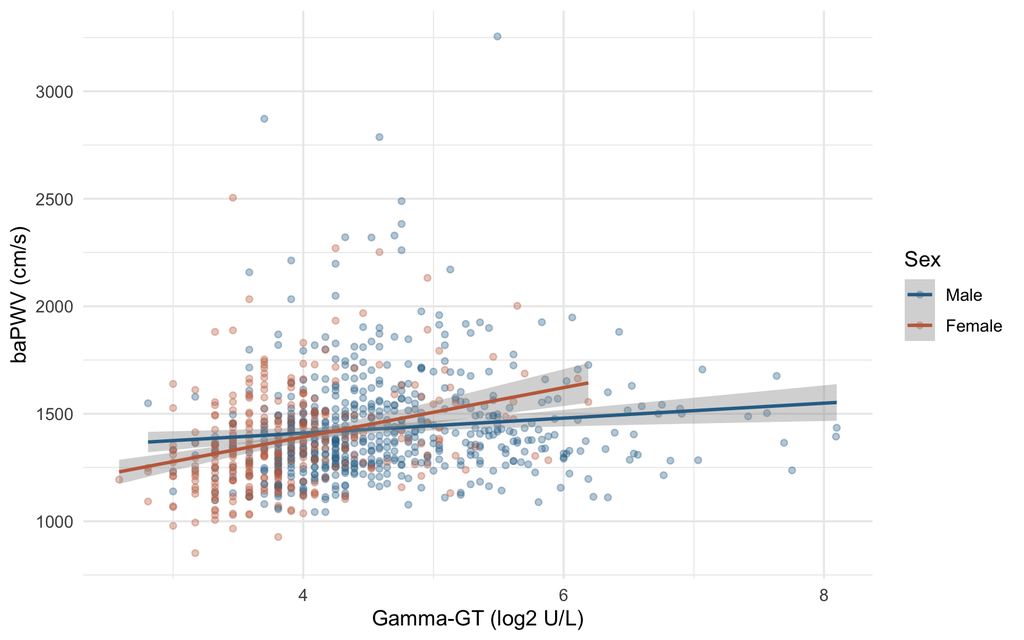

Figure 1. Pulse-wave velocity against log2 gamma-GT, by sex, with linear smooths.

## Univariable models

| **Characteristic** | **N** | **Beta** | **95% CI** | **p-value** |
| --- | --- | --- | --- | --- |
| Age (years) | 883 | 13 | 11, 14 | <0.001 |
| Sex | 883 |  |  |  |
| Male |  | — | — |  |
| Female |  | -52 | -85, -18 | 0.002 |
| BMI (kg/m2) | 883 | 5.0 | -0.09, 10 | 0.054 |
| Systolic BP (mmHg) | 883 | 8.4 | 7.5, 9.3 | <0.001 |
| Smoking status | 883 |  |  |  |
| Never |  | — | — |  |
| Former |  | 41 | 3.3, 79 | 0.033 |
| Current |  | 19 | -22, 60 | 0.4 |
| Alcohol (g/week) | 883 | 0.08 | -0.04, 0.20 | 0.2 |
| Takes regular exercise | 883 |  |  |  |
| No |  | — | — |  |
| Yes |  | 16 | -24, 56 | 0.4 |
| Fasting glucose (mg/dL) | 883 | 4.1 | 3.0, 5.2 | <0.001 |
| Triglycerides (mg/dL) | 883 | 0.44 | 0.23, 0.66 | <0.001 |
| HDL cholesterol (mg/dL) | 883 | -1.2 | -2.3, -0.13 | 0.029 |
| eGFR (mL/min/1.73m2) | 883 | -6.2 | -7.4, -4.9 | <0.001 |
| Gamma-GT (log2 U/L) | 883 | 56 | 38, 75 | <0.001 |

Abbreviation: CI = Confidence Interval

Age and systolic pressure dominate the crude picture. Each additional year of age is associated with 12.7 cm/s (95% CI 11.2 to 14.1) higher baPWV (p <0.001), roughly 127 cm/s per decade, and each additional mmHg of systolic pressure with 8.4 cm/s (95% CI 7.5 to 9.3) (p <0.001). Each doubling of gamma-GT is associated with 56.3 cm/s (95% CI 37.8 to 74.7) higher baPWV (p <0.001) - a substantial crude association, and the one the source paper was built around. Higher fasting glucose (4.1 cm/s (95% CI 3.0 to 5.2) per mg/dL, p <0.001) and higher triglycerides (0.4 cm/s (95% CI 0.2 to 0.7) per mg/dL, p <0.001) also mark stiffer arteries, while better kidney function is associated with less stiffness (-6.2 cm/s (95% CI -7.4 to -4.9) per unit of eGFR, p <0.001). Women average -51.8 cm/s (95% CI -85.3 to -18.4) relative to men (p = 0.002), and former smokers 41.0 cm/s (95% CI 3.3 to 78.6) relative to never-smokers (p = 0.033) - though current smokers do not differ (19.3 cm/s (95% CI -21.7 to 60.4), p = 0.356), which is not the ordering one would expect from a causal smoking effect. BMI (5.0 cm/s (95% CI -0.1 to 10.2), p = 0.054), alcohol (0.1 cm/s (95% CI -0.0 to 0.2), p = 0.203) and regular exercise (16.4 cm/s (95% CI -23.6 to 56.3), p = 0.422) show no crude association.

## Why adjustment is needed

**Age** is the single most important confounder in this dataset. It is associated with baPWV more strongly than anything else except pressure (r = 0.49), and it is strongly associated with kidney function (r = -0.40 with eGFR) and more weakly with fasting glucose (r = 0.14). The crude eGFR association is therefore substantially an age association wearing a kidney’s clothes: older attendees have both lower eGFR and stiffer arteries for reasons that have little to do with the kidney itself. Note that age is *not* a confounder of the pressure association here - age and systolic pressure correlate only r = 0.10 in this screening cohort - which is why the two of them together carry so much of the model without competing.

**Sex** confounds the gamma-GT association. Men in this cohort have far higher GGT than women (median 4.39 versus 3.81 on the log2 scale, i.e. about 1.5-fold higher on the raw scale) because they drink far more (median alcohol 36 versus 0 g per week), and men also have higher baPWV. **Alcohol** is the third variable that must be handled explicitly, for the same reason from the other direction: it drives GGT (r = 0.33 with log2 GGT) and is itself associated with cardiovascular risk, so a crude GGT coefficient is partly a drinking coefficient. **Systolic pressure** confounds - or mediates - almost everything, since adiposity, glucose and smoking all raise pressure and pressure raises measured baPWV. Mutual adjustment lets each coefficient be read as a comparison between attendees alike on the other measured characteristics, with the pressure caveat kept in view.

## Multivariable model

| **Characteristic** | **Beta** | **95% CI** | **p-value** |
| --- | --- | --- | --- |
| Age (years) | 10 | 9.1, 12 | <0.001 |
| Sex |  |  |  |
| Male | — | — |  |
| Female | 4.3 | -29, 38 | 0.8 |
| BMI (kg/m2) | -11 | -15, -6.6 | <0.001 |
| Systolic BP (mmHg) | 8.0 | 7.1, 8.8 | <0.001 |
| Smoking status |  |  |  |
| Never | — | — |  |
| Former | 12 | -19, 43 | 0.4 |
| Current | 44 | 10, 78 | 0.011 |
| Alcohol (g/week) | -0.12 | -0.21, -0.02 | 0.018 |
| Takes regular exercise |  |  |  |
| No | — | — |  |
| Yes | -24 | -54, 5.1 | 0.10 |
| Fasting glucose (mg/dL) | 1.4 | 0.53, 2.3 | 0.002 |
| Triglycerides (mg/dL) | 0.06 | -0.13, 0.24 | 0.5 |
| HDL cholesterol (mg/dL) | -0.27 | -1.2, 0.70 | 0.6 |
| eGFR (mL/min/1.73m2) | -1.3 | -2.4, -0.22 | 0.018 |
| Gamma-GT (log2 U/L) | 14 | -2.7, 31 | 0.10 |

Abbreviation: CI = Confidence Interval

**Model fit: multivariable linear model for baPWV**

| Statistic | Value |
| --- | --- |
| Complete-case N | 883 |
| Parameters (excl. intercept) | 13 |
| Observations per parameter | 67.9 |
| R-squared | 0.498 |
| Adjusted R-squared | 0.491 |
| Residual SE (cm/s) | 172.8 |
| SD of outcome (cm/s) | 242.2 |

The model explains 49.8% of the variance in baPWV (adjusted R-squared 0.491), which is high for an observational model of this kind and is almost entirely the work of age and systolic pressure. Residual SE is 172.8 cm/s against an outcome SD of 242.2 cm/s.

Among attendees of the same sex, body mass, blood pressure, smoking, drinking, exercise, glucose, lipids, kidney function and gamma-GT, each additional year of age is associated with 10.5 cm/s (95% CI 9.1 to 11.8) higher baPWV (p <0.001), and among attendees alike on everything else each additional mmHg of systolic pressure with 8.0 cm/s (95% CI 7.1 to 8.8) (p <0.001). Two coefficients change character on adjustment. BMI, which showed no crude association, becomes -10.9 cm/s (95% CI -15.1 to -6.6) per kg/m2 (p <0.001) - *lower* stiffness at higher BMI once pressure and the metabolic variables are held constant. Current smoking, which was null crudely, becomes 44.0 cm/s (95% CI 10.2 to 77.9) relative to never smoking (p = 0.011), while former smoking is 12.1 cm/s (95% CI -19.1 to 43.2) (p = 0.448). Higher fasting glucose remains associated with stiffer arteries (1.4 cm/s (95% CI 0.5 to 2.3) per mg/dL, p = 0.002), higher alcohol intake with slightly less stiffness (-0.1 cm/s (95% CI -0.2 to -0.0) per g/week, p = 0.018), and better kidney function with less stiffness (-1.3 cm/s (95% CI -2.4 to -0.2), p = 0.018).

**Gamma-GT does not survive adjustment.** Each doubling of GGT is associated with 13.9 cm/s (95% CI -2.7 to 30.5) (p = 0.101), against a crude 56.3 cm/s (95% CI 37.8 to 74.7): the point estimate has fallen by about 75% and the confidence interval now includes zero. Sex, triglycerides, HDL cholesterol and regular exercise are also not independently associated. These are associations among the attendees observed, not effects of intervening.

**Sensitivity: gamma-GT with and without systolic pressure in the model**

| Model | log2 gamma-GT coefficient | p | R-squared |
| --- | --- | --- | --- |
| Main model (systolic BP included) | 13.9 cm/s (95% CI -2.7 to 30.5) | 0.101 | 0.498 |
| Sensitivity model (systolic BP omitted) | 27.5 cm/s (95% CI 8.1 to 46.9) | 0.005 | 0.311 |

This is the honest version of the gamma-GT finding. With systolic pressure in the model, GGT contributes 13.9 cm/s (95% CI -2.7 to 30.5) (p = 0.101); with pressure removed it contributes 27.5 cm/s (95% CI 8.1 to 46.9) (p = 0.005), roughly 2.0 times larger and clearly significant. Because pressure and stiffness are mutually causal - and because baPWV is measured *from* a pressure waveform - neither number is the “true” GGT effect. The pressure-adjusted estimate is conservative to the point of being an over-adjustment; the unadjusted-for-pressure estimate contains whatever part of the GGT-stiffness link runs through blood pressure. The defensible statement is that any independent contribution of GGT to arterial stiffness in this cohort is small, and that most of the crude association is explained by age, sex, drinking and pressure.

## Unadjusted versus adjusted

**Table 2. Unadjusted and adjusted estimates.**

| **Characteristic** | **Unadjusted** **N** | **Unadjusted** **Beta** | **Unadjusted** **95% CI** | **Unadjusted** **p-value** | **Adjusted** **Beta** | **Adjusted** **95% CI** | **Adjusted** **p-value** |
| --- | --- | --- | --- | --- | --- | --- | --- |
| Age (years) | 883 | 13 | 11, 14 | <0.001 | 10 | 9.1, 12 | <0.001 |
| Sex | 883 |  |  |  |  |  |  |
| Male |  | — | — |  | — | — |  |
| Female |  | -52 | -85, -18 | 0.002 | 4.3 | -29, 38 | 0.8 |
| BMI (kg/m2) | 883 | 5.0 | -0.09, 10 | 0.054 | -11 | -15, -6.6 | <0.001 |
| Systolic BP (mmHg) | 883 | 8.4 | 7.5, 9.3 | <0.001 | 8.0 | 7.1, 8.8 | <0.001 |
| Smoking status | 883 |  |  |  |  |  |  |
| Never |  | — | — |  | — | — |  |
| Former |  | 41 | 3.3, 79 | 0.033 | 12 | -19, 43 | 0.4 |
| Current |  | 19 | -22, 60 | 0.4 | 44 | 10, 78 | 0.011 |
| Alcohol (g/week) | 883 | 0.08 | -0.04, 0.20 | 0.2 | -0.12 | -0.21, -0.02 | 0.018 |
| Takes regular exercise | 883 |  |  |  |  |  |  |
| No |  | — | — |  | — | — |  |
| Yes |  | 16 | -24, 56 | 0.4 | -24 | -54, 5.1 | 0.10 |
| Fasting glucose (mg/dL) | 883 | 4.1 | 3.0, 5.2 | <0.001 | 1.4 | 0.53, 2.3 | 0.002 |
| Triglycerides (mg/dL) | 883 | 0.44 | 0.23, 0.66 | <0.001 | 0.06 | -0.13, 0.24 | 0.5 |
| HDL cholesterol (mg/dL) | 883 | -1.2 | -2.3, -0.13 | 0.029 | -0.27 | -1.2, 0.70 | 0.6 |
| eGFR (mL/min/1.73m2) | 883 | -6.2 | -7.4, -4.9 | <0.001 | -1.3 | -2.4, -0.22 | 0.018 |
| Gamma-GT (log2 U/L) | 883 | 56 | 38, 75 | <0.001 | 14 | -2.7, 31 | 0.10 |

Abbreviation: CI = Confidence Interval

Three predictors move a long way. **Sex** collapses from -51.8 cm/s (95% CI -85.3 to -18.4) crude (p = 0.002) to 4.3 cm/s (95% CI -29.0 to 37.5) adjusted (p = 0.801) - the entire apparent sex difference in arterial stiffness is explained by the other measured characteristics, and the coefficient crosses from clearly significant to null and even changes sign. Systolic pressure does almost all of that work on its own: adding it alone to the crude model moves the female coefficient from -51.8 to 12.3 cm/s, because the women in this cohort have median systolic pressure 114.5 mmHg against 121.5 mmHg in the men. **Gamma-GT** falls from 56.3 cm/s (95% CI 37.8 to 74.7) to 13.9 cm/s (95% CI -2.7 to 30.5) and likewise loses significance (p <0.001 to p = 0.101), which is confounding by age, sex and alcohol exactly as anticipated. **BMI** moves in the opposite direction, and *through* the null: from 5.0 cm/s (95% CI -0.1 to 10.2) crude (p = 0.054) to -10.9 cm/s (95% CI -15.1 to -6.6) adjusted (p <0.001). This sign reversal is not a paradox but a classic suppression pattern: heavier attendees have higher blood pressure, glucose and triglycerides, all of which raise baPWV, so crudely BMI looks neutral or slightly harmful; once those downstream consequences are held fixed, the residual association of body mass with measured stiffness is negative, partly because baPWV in a larger limb is measured over a longer, more muscular path. **Triglycerides** and **eGFR** both attenuate strongly toward the null (triglycerides 0.4 cm/s (95% CI 0.2 to 0.7) to 0.1 cm/s (95% CI -0.1 to 0.2), losing significance; eGFR -6.2 cm/s (95% CI -7.4 to -4.9) to -1.3 cm/s (95% CI -2.4 to -0.2), retaining it but at about 21% of the crude magnitude) - both were largely age.

Two things barely move. **Systolic pressure** goes from 8.4 cm/s (95% CI 7.5 to 9.3) to 8.0 cm/s (95% CI 7.1 to 8.8), essentially unchanged, and **age** from 12.7 cm/s (95% CI 11.2 to 14.1) to 10.5 cm/s (95% CI 9.1 to 11.8): these two are not explained by anything else in the file, which is why they carry the model. Finally, **smoking changes which level is significant**: crudely it is former smoking that differs from never (41.0 cm/s (95% CI 3.3 to 78.6), p = 0.033) while current smoking does not (19.3 cm/s (95% CI -21.7 to 60.4), p = 0.356); after adjustment the pattern inverts, with current smoking at 44.0 cm/s (95% CI 10.2 to 77.9) (p = 0.011) and former smoking null (12.1 cm/s (95% CI -19.1 to 43.2), p = 0.448). The crude former-smoker signal was age and sex - former smokers are the oldest group - and once that is removed the dose-response one expects from smoking appears.

## Diagnostics

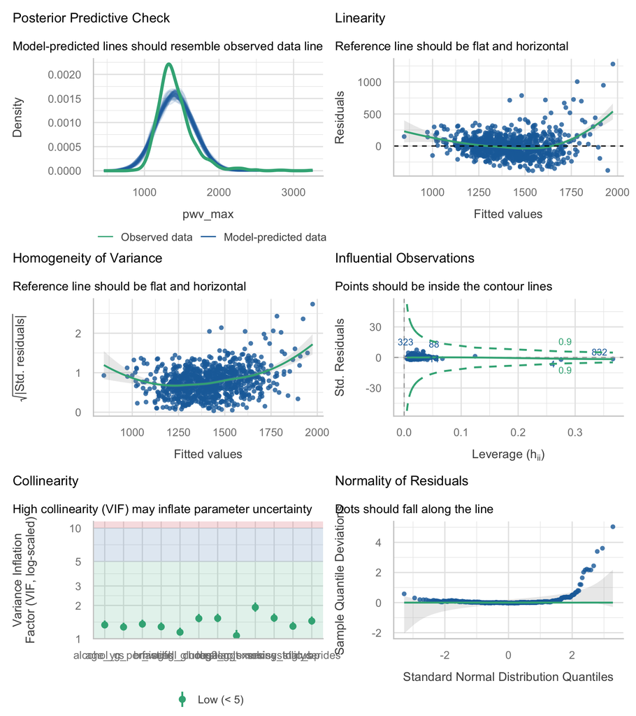

| Term | VIF | VIF_CI_low | VIF_CI_high | SE_factor | Tolerance | Tolerance_CI_low | Tolerance_CI_high |
| --- | --- | --- | --- | --- | --- | --- | --- |
| age_yrs | 1.332983 | 1.240868 | 1.460326 | 1.154549 | 0.7501970 | 0.6847786 | 0.8058875 |
| sex | 1.922861 | 1.755881 | 2.126727 | 1.386673 | 0.5200585 | 0.4702062 | 0.5695145 |
| bmi | 1.356334 | 1.261063 | 1.486371 | 1.164617 | 0.7372816 | 0.6727793 | 0.7929815 |
| systolic_bp | 1.296244 | 1.209188 | 1.419530 | 1.138527 | 0.7714596 | 0.7044587 | 0.8270011 |
| smoking_status | 1.538221 | 1.419285 | 1.690895 | 1.113665 | 0.6501016 | 0.5914029 | 0.7045800 |
| alcohol_g_per_week | 1.275352 | 1.191239 | 1.396462 | 1.129315 | 0.7840971 | 0.7160955 | 0.8394622 |
| regular_exercise | 1.066814 | 1.022280 | 1.200366 | 1.032867 | 0.9373705 | 0.8330796 | 0.9782057 |
| fasting_glucose | 1.145786 | 1.082162 | 1.258678 | 1.070414 | 0.8727636 | 0.7944841 | 0.9240763 |
| triglycerides | 1.447080 | 1.339849 | 1.588144 | 1.202946 | 0.6910470 | 0.6296659 | 0.7463526 |
| hdl_cholesterol | 1.525252 | 1.407969 | 1.676252 | 1.235011 | 0.6556293 | 0.5965691 | 0.7102429 |

[output cut: 2 more lines]

**Table 3. HC3 heteroscedasticity-consistent standard errors.**

| Term | Estimate | SE (OLS) | SE (HC3) | 95% CI (HC3) | p (HC3) |
| --- | --- | --- | --- | --- | --- |
| age_yrs | 10.45 | 0.71 | 0.86 | 8.8 to 12.1 | 0.000 |
| sexFemale | 4.27 | 16.93 | 15.86 | -26.9 to 35.4 | 0.788 |
| bmi | -10.86 | 2.18 | 2.28 | -15.3 to -6.4 | 0.000 |
| systolic_bp | 7.98 | 0.44 | 0.60 | 6.8 to 9.1 | 0.000 |
| smoking_statusFormer | 12.06 | 15.87 | 15.11 | -17.6 to 41.7 | 0.425 |
| smoking_statusCurrent | 44.03 | 17.25 | 18.19 | 8.3 to 79.7 | 0.016 |
| alcohol_g_per_week | -0.12 | 0.05 | 0.06 | -0.2 to -0.0 | 0.043 |
| regular_exerciseYes | -24.36 | 15.00 | 16.57 | -56.9 to 8.2 | 0.142 |
| fasting_glucose | 1.39 | 0.44 | 0.63 | 0.2 to 2.6 | 0.028 |
| triglycerides | 0.06 | 0.09 | 0.14 | -0.2 to 0.3 | 0.687 |
| hdl_cholesterol | -0.27 | 0.49 | 0.54 | -1.3 to 0.8 | 0.612 |
| egfr | -1.30 | 0.55 | 0.57 | -2.4 to -0.2 | 0.023 |
| log2_ggt | 13.91 | 8.47 | 8.72 | -3.2 to 31.0 | 0.111 |

**Collinearity is not a problem in the reduced model.** The largest VIF is 1.92 (sex), and every VIF is below 2.0; nothing approaches the conventional threshold of 5. This is the direct pay-off of the a-priori cut: in the 18-predictor version of this model the largest VIF is 23.9.

**Variance is not constant and residuals are not normal.** The residual-versus-fitted panel fans out clearly as fitted baPWV rises, and `check_heteroscedasticity()` rejects (p <0.001); the normal-QQ panel shows a heavy right tail and `check_normality()` also rejects (p <0.001). Both are driven by the right skew of baPWV (skewness 1.90): the stiffest arteries are also the most variable, so the spread of the outcome grows with its mean. The posterior-predictive check shows the same thing - the fitted symmetric distribution cannot reproduce the tail above about 2,000 cm/s. Table 3 therefore reports HC3 robust standard errors. They are modestly wider for the strongest predictors (age: OLS SE 0.71 versus HC3 0.86; systolic pressure 0.44 versus 0.60) but **no coefficient changes its significance status**, so the substantive conclusions stand. Modelling `log(pwv_max)` improves R-squared slightly (to 0.525) but does **not** fix either check, so the skew is not a simple multiplicative problem.

**No single observation drives the fit.** The largest Cook’s distance is 0.113 and the largest leverage 0.366, both far inside the usual contours, and the influence panel shows no point outside them.

# Discussion

In this Japanese health-check cohort, arterial stiffness measured as baPWV is overwhelmingly a function of age and systolic blood pressure: each decade of age is associated with about 105 cm/s and each 10 mmHg of systolic pressure with about 80 cm/s, holding everything else constant, and together with the remaining predictors these account for 50% of the variance. The crude association between gamma-GT and stiffness - 56.3 cm/s (95% CI 37.8 to 74.7) per doubling of GGT - does not survive mutual adjustment (13.9 cm/s (95% CI -2.7 to 30.5)), and the residual signal that does appear when blood pressure is left out of the model (27.5 cm/s (95% CI 8.1 to 46.9)) is plausibly routed through pressure rather than independent of it. Practically, this argues that GGT adds little to age and blood pressure for identifying stiff arteries in a screening setting, and that a report claiming a liver-enzyme contribution to arterial stiffness needs to be explicit about what it did with blood pressure.

**Limitations.** The design is cross-sectional, so nothing here establishes temporal order; stiff arteries and raised GGT could both be consequences of a shared metabolic process, and reverse causation cannot be excluded. Adjusting for systolic pressure is not clean confounder control: pressure is on the causal path between most of these risk factors and stiffness, and baPWV is derived from a pressure waveform, so the pressure-adjusted coefficients are probably over-adjusted while the unadjusted-for-pressure ones are under-adjusted - the sensitivity table brackets rather than resolves this. Health-check attendees are a self-selected group who are healthier and better resourced than the general Japanese population, which compresses the range of every risk factor and will attenuate associations relative to a community sample. Residual variance is non-constant and residuals are strongly right-skewed; HC3 standard errors repair inference but not the model’s inability to predict the stiffest attendees. Alcohol is self-reported in g/week with 285 attendees reporting exactly zero, so misreporting is likely and probably differential by sex. Antihypertensive, lipid-lowering and glucose-lowering medication is not recorded at all, which is a serious unmeasured confounder: treated hypertensives appear in the data with near-normal pressures but stiff arteries. Diet, socioeconomic position and diabetes duration are likewise absent. 29 of 912 rows were dropped for missing exercise or alcohol. All estimates are associations, not causal effects.

**Future work.** Refit on the log scale with medication use and a repeated baPWV measurement, and treat blood pressure explicitly as a mediator with a formal decomposition rather than as a covariate to be switched on and off.

# Feasibility notes

*NOT part of a student report.*

- **Verdict: USABLE.** This is one of the better linear outcomes in the catalogue. `pwv_max` is complete (0 missing), well spread, and has two genuinely strong predictors, so a student’s model will “work” and produce an R-squared of about 0.50. The interesting teaching content is that the headline exposure of the source paper (GGT) *does not* survive.
- **MAJOR: 18 suggested predictors is too many and the budget rule will not stop a student.** With 883 complete cases, even 20 parameters gives ~44 observations per parameter, so the 10-15 observations-per-parameter rule gives no reason to cut. Students will therefore fit all 18 unless the brief tells them not to, and the resulting table is unreadable *and* collinear. The cut has to be justified on redundancy and interpretability, which is a harder argument for a student to construct unaided. Consider trimming the suggested list in `meta.json`.
- **MAJOR collinearity if the lipids are all included.** In the 18-predictor model the VIFs are 23.9 (total cholesterol), 19.7 (LDL), 5.5 (HDL) and 4.6 (triglycerides). Regressing total cholesterol on the other three gives R-squared 0.955 with coefficients 1.00 / 1.06 / 0.17, i.e. the Friedewald identity total = LDL + HDL + triglycerides/5 holds to within rounding. Note it is *near*-deterministic, not exact: LDL here appears to be directly measured, so `total_cholesterol - hdl_cholesterol - triglycerides/5` differs from `ldl_cholesterol` by a median of about 8.0 mg/dL. The model does not become singular; it becomes uninterpretable, which is worse because nothing warns the student.
- **MAJOR collinearity between the blood pressures.** r = 0.90; VIFs 5.4 and 5.7 when both are included. With both in, the diastolic coefficient is essentially zero and the systolic one absorbs everything.
- **MAJOR conceptual trap: systolic pressure is partly the outcome.** baPWV is computed from a cuff pressure waveform and is pressure-dependent by construction. Including systolic pressure drives GGT from 27.5 cm/s (95% CI 8.1 to 46.9) (p = 0.005) to 13.9 cm/s (95% CI -2.7 to 30.5) (p = 0.101), which is the difference between “GGT is associated with arterial stiffness” and “it is not”. Any student conclusion about GGT is therefore an artefact of a covariate choice they will not have thought about. This should be flagged in `meta.json` cautions.
- **MAJOR: failed diagnostics.** Heteroscedasticity p <0.001 and non-normality of residuals p <0.001, both from the right skew of baPWV (skewness 1.90). A log transformation raises R-squared only slightly and does *not* clear either test, so there is no easy fix; students must report a failed check and use robust SEs. Reassuringly, no coefficient changes significance under HC3.
- **MINOR: BMI reverses sign on adjustment** (5.0 cm/s (95% CI -0.1 to 10.2) crude to -10.9 cm/s (95% CI -15.1 to -6.6) adjusted, p <0.001). This is a suppression effect via blood pressure and the metabolic variables, and it is a good teaching moment, but a weak student will report “obesity protects the arteries”.
- **MINOR: smoking swaps which level is significant** between the crude and adjusted models (former significant crude, current significant adjusted). With 191 current and 247 former smokers there is enough data for the contrast, but note that smoking is almost entirely a male behaviour here (17 female current smokers out of 320 women), so smoking and sex are heavily entangled.
- **MINOR: complete-case loss is small** - 883 of 912 (3.2%), driven entirely by `regular_exercise` (16) and `alcohol_g_per_week` (13). No predictor here silently costs a large share of the sample.
- **MINOR: no medication variables.** Antihypertensives, statins and glucose-lowering drugs are not in the file. For an outcome this dependent on blood pressure that is a substantial unmeasured confounder and should be in the cautions.
- **On the >= 1400 cm/s dichotomisation offered in the catalogue: it works, but it is strictly worse.** `pwv_max >= 1400` gives 405 / 912 (44.4%) events, and in the complete-case sample 390 events for 13 parameters, i.e. 30.0 events per parameter - comfortably feasible, no separation, and the logistic model recovers the same ordering of predictors (age and systolic pressure dominant, Tjur’s R-squared 0.35). But the threshold is arbitrary rather than clinical, it throws away a well-measured continuous outcome, and its binned-residual check also fails (only 77% of bins inside the error bounds). The catalogue is right to present `pwv_max` as linear; the “either” designation in `meta.json` should not be read as an invitation.
- No separation issues arise anywhere in the linear model, and there are no deterministic relationships between `pwv_max` and any shipped column (`abi_max` is the closest structurally related variable and correlates r = 0.01 with it, i.e. not at all).